# Predictive Text Generator - Part II

Aditya Iyengar

18/04/2020

## Overview

This document explains the actual structure of the n-gram predictive text generator model. The data is loaded, cleaned and split into training, test and validation sets. First, a basic model is applied to the test set, following which multiple advanced models with several parameters are trained. Some sample output cases are also displayed to illustrate how the model actually works.

## Loading the Datasets

Download the datasets from [here](https://d396qusza40orc.cloudfront.net/dsscapstone/dataset/Coursera-SwiftKey.zip) and store them in the working directory. We will currently work with the English (US) datasets only.

```r
conblogs <- file("./Coursera-SwiftKey/final/en_US/en_US.blogs.txt")
connews <- file("./Coursera-SwiftKey/final/en_US/en_US.news.txt")
contwitter <- file("./Coursera-SwiftKey/final/en_US/en_US.twitter.txt")

suppressWarnings(blogs <- readLines(conblogs))
suppressWarnings(news <- readLines(connews))
suppressWarnings(twitter <- readLines(contwitter))

close(conblogs);
close(connews);
close(contwitter)
```

Just as we did in [Part I](https://rpubs.com/adityaiyengar/601052), we will sample a fraction of the tests. This fraction was prescribed to be 10% of the blogs, 100% of the news articles and 10% of the Twitter posts.

```r
set.seed(1234)
samplelines <- c(sample(blogs, length(blogs) * 0.1),
                 sample(news, length(news)),
                 sample(twitter, length(twitter) * 0.1))
```

## Splitting the Datasets

We shuffle the dataset comprising the sampled text and divide it into training, validation and test sets. 80% of the set is allocated for training while the rest is equally divided into validation and test sets.

```r
set.seed(1234)
samplelines <- sample(samplelines)
valindex <- floor(length(samplelines) * 0.8)
testindex <- floor(length(samplelines) * 0.9)

training <- samplelines[1:valindex]
validation <- samplelines[(valindex+1):testindex]
test <- samplelines[(testindex+1):length(samplelines)]
```

## Cleaning the Datasets

As in the exploratory analysis, we will tidy the datasets. We define a function to generate tokens which will be used in further modelling. The function splits the lines on any character that isn’t a letter or an apostrophe.

```r
tokenizer <- function(lines) {
    lines <- tolower(lines)
    lines <- gsub("'", "'", lines)
    lines <- gsub("[.!?]$|[.!?] |$", " ''split'' ", lines)
    tokens <- unlist(strsplit(lines, "[^a-z']"))
    tokens <- tokens[tokens != ""]
    return(tokens)
}

tokens <- tokenizer(training)
valtokens <- tokenizer(validation)
testtokens <- tokenizer(test)
```

## Generating Frequencies for n-grams

We would now like to answer the question - *How many times does a particular n-gram appear during training?*

First of all, we shift the tokens by one token at a time by removing the first token and add a dummy token (.) at the end. We will work upto 6-grams.

```r
tokens2 <- c(tokens[-1], ".")
tokens3 <- c(tokens2[-1], ".")
tokens4 <- c(tokens3[-1], ".")
tokens5 <- c(tokens4[-1], ".")
tokens6 <- c(tokens5[-1], ".")
```

Now we paste the first n tokens to generate the list of n-grams.

```r
onegram <- tokens
twogram <- paste(tokens, tokens2)
threegram <- paste(tokens, tokens2, tokens3)
fourgram <- paste(tokens, tokens2, tokens3, tokens4)
fivegram <- paste(tokens, tokens2, tokens3, tokens4, tokens5)
sixgram <- paste(tokens, tokens2, tokens3, tokens4, tokens5, tokens6)
```

We had created demarcations (‘split’) for the sentence boundaries. Given these markers, we can remove those n-grams that include parts of two different sentences because they wouldn’t make any coherent sense.

```r
onegram <- onegram[!grepl("''split''", onegram)]
twogram <- twogram[!grepl("''split''", twogram)]
threegram <- threegram[!grepl("''split''", threegram)]
fourgram <- fourgram[!grepl("''split''", fourgram)]
fivegram <- fivegram[!grepl("''split''", fivegram)]
sixgram <- sixgram[!grepl("''split''", sixgram)]
```

Great! Now we have n-grams all of which lie entirely in one sentence. We now sort these n-grams in decreasing order of their frequency.

```r
onegram <- sort(table(onegram), decreasing=TRUE)
twogram <- sort(table(twogram), decreasing=TRUE)
threegram <- sort(table(threegram), decreasing=TRUE)
fourgram <- sort(table(fourgram), decreasing=TRUE)
fivegram <- sort(table(fivegram), decreasing=TRUE)
sixgram <- sort(table(sixgram), decreasing=TRUE)
```

Let’s look at the top 10 n-grams visually.

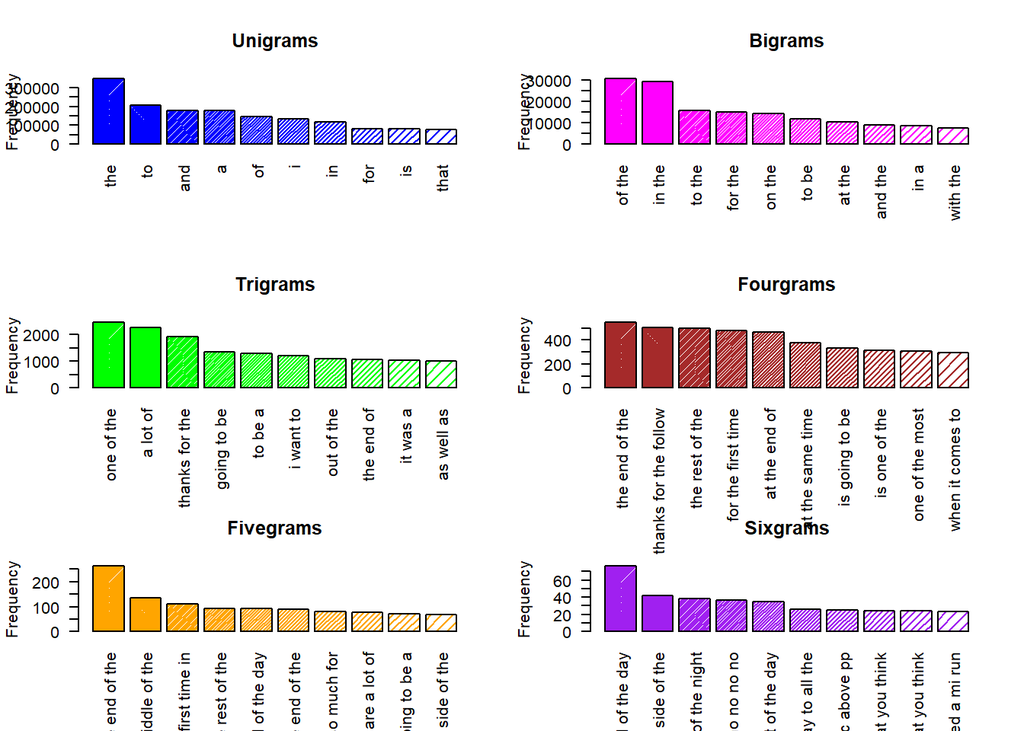

```r
par(mfrow = c(3,2))
barplot(as.numeric(onegram[1:10]), names.arg=names(onegram[1:10]), las=2, col="blue", border="black", density=seq(100, 10, -9), main = "Unigrams", ylab = "Frequency")
barplot(as.numeric(twogram[1:10]), names.arg=names(twogram[1:10]), las=2, col="magenta", border="black", density=seq(100, 10, -9), main = "Bigrams", ylab = "Frequency")
barplot(as.numeric(threegram[1:10]), names.arg=names(threegram[1:10]), las=2, col="green", border="black", density=seq(100, 10, -9), main = "Trigrams", ylab = "Frequency")
barplot(as.numeric(fourgram[1:10]), names.arg=names(fourgram[1:10]), las=2, col="brown", border="black", density=seq(100, 10, -9), main = "Fourgrams", ylab = "Frequency")
barplot(as.numeric(fivegram[1:10]), names.arg=names(fivegram[1:10]), las=2, col="orange", border="black", density=seq(100, 10, -9), main = "Fivegrams", ylab = "Frequency")
barplot(as.numeric(sixgram[1:10]), names.arg=names(sixgram[1:10]), las=2, col="purple", border="black", density=seq(100, 10, -9), main = "Sixgrams", ylab = "Frequency")
```